# Word Segmentation Analysis

June 2022

## Load Packages

```r
rm(list=ls())
# setwd("../Data/CSV")

library(data.table)
library(tidyverse)
library(ggrepel)
library(emmeans)
library(ggeffects)
library(ggpubr)
library(lmerTest)
```

```r
# library(rjson)
# library(jsonlite)

library(corrplot)
library(ggcorrplot)

theme_set(theme_bw())
theme_set(theme(plot.title = element_text(size =9),  panel.grid.major = element_blank(),
    panel.grid.minor = element_blank(),
    legend.position = "bottom"))
```

## RQs

RQ: What are the differences in segmentability between CDS and ADS?

- lm(f_score ~ algo * type * Unit)

RQ: How do corpus properties affect word segmentation?

- lm(f_score ~ proportion_of_single_word_utt * algo * Unit + phrase_s * algo * Unit + word_s * algo * Unit + each_mattr * algo * Unit + each_entropy * algo * Unit + proportion_of_hapaxes_words * algo * Unit + algo * Unit, data = dflmregialgo)

RQ: Do corpus properties of CDS differ from those of ADS in Korean? (controlling for corpus size)

Modeling on each corpus property respectively:

- lm(values ~ type * each_words_tokens)

## RQs

RQ: How do corpus properties affect word segmentation?

- lm(f_score ~ proportion_of_single_word_utt + phrase_s + word_s + each_mattr + each_entropy + proportion_of_hapaxes_words + algo * type * Unit + type * each_words_tokens, data = dflmregialgo)
  - corpus properties = proportion_of_single_word_utt + phrase_s + word_s + each_mattr + each_entropy + proportion_of_hapaxes_words
  - algo * type * Unit for checking main effects whether are cancalled out by corpus properties
  - type * each_words_tokens for controlling the effect of corpus size and register (is this neccessary? if the purpose is to observe the effect of corpus properties independent of corpus properties?)

## Q1/2) Corpus Analysis comparing ADS and CDS

## ANOVA Q1/2) Corpus Analysis comparing ADS and CDS

|  | Sum Sq | Df | F value | Pr(>F) |
| --- | --- | --- | --- | --- |
| (Intercept) | 3.48412017 | 1 | 610.300202 | 8.590353e-56 |
| TotalTokenNumber | 0.05173615 | 1 | 9.062426 | 3.043991e-03 |
| type | 0.05824755 | 2 | 5.101502 | 7.143102e-03 |
| Residuals | 0.89058261 | 156 | NA | NA |

## ANOVA Q1/2) Corpus Analysis comparing ADS and CDS

|  | Sum Sq | Df | F value | Pr(>F) |
| --- | --- | --- | --- | --- |
| (Intercept) | 2121.6496 | 1 | 387.91365 | 3.709906e-44 |
| TotalTokenNumber | 113.3882 | 1 | 20.73142 | 1.058246e-05 |
| type | 699.0679 | 2 | 63.90735 | 5.333327e-21 |
| Residuals | 853.2243 | 156 | NA | NA |

## ANOVA Q1/2) Corpus Analysis comparing ADS and CDS

|  | Sum Sq | Df | F value | Pr(>F) |
| --- | --- | --- | --- | --- |
| (Intercept) | 86.7849819 | 1 | 6570.65276 | 2.018867e-129 |
| TotalTokenNumber | 0.1424243 | 1 | 10.78321 | 1.264475e-03 |
| type | 0.4064082 | 2 | 15.38496 | 7.975867e-07 |
| Residuals | 2.0604433 | 156 | NA | NA |

## ANOVA Q1/2) Corpus Analysis comparing ADS and CDS

|  | Sum Sq | Df | F value | Pr(>F) |
| --- | --- | --- | --- | --- |
| (Intercept) | 2.440478e+01 | 1 | 1.814961e+04 | 2.447150e-163 |
| TotalTokenNumber | 7.862041e-04 | 1 | 5.846928e-01 | 4.456339e-01 |
| type | 1.959307e-01 | 2 | 7.285593e+01 | 4.523905e-23 |
| Residuals | 2.097646e-01 | 156 | NA | NA |

## ANOVA Q1/2) Corpus Analysis comparing ADS and CDS

|  | Sum Sq | Df | F value | Pr(>F) |
| --- | --- | --- | --- | --- |
| (Intercept) | 0.0110683628 | 1 | 431.272568 | 9.224820e-47 |
| TotalTokenNumber | 0.0000817680 | 1 | 3.186044 | 7.621276e-02 |
| type | 0.0001733512 | 2 | 3.377267 | 3.665534e-02 |
| Residuals | 0.0040036504 | 156 | NA | NA |

## ANOVA Q1/2) Corpus Analysis comparing ADS and CDS

|  | Sum Sq | Df | F value | Pr(>F) |
| --- | --- | --- | --- | --- |
| (Intercept) | 7.51773547 | 1 | 4163.88347 | 2.039228e-114 |
| TotalTokenNumber | 0.04720195 | 1 | 26.14397 | 9.172135e-07 |
| type | 0.31958966 | 2 | 88.50631 | 2.050142e-26 |
| Residuals | 0.28165215 | 156 | NA | NA |

## Q1/2) Corpus Analysis comparing ADS and CDS

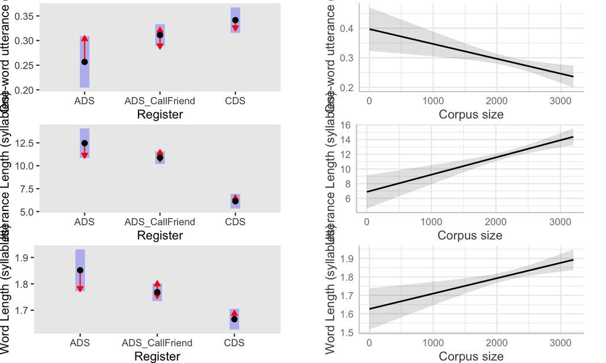

## Q1/2) Corpus Analysis comparing ADS and CDS

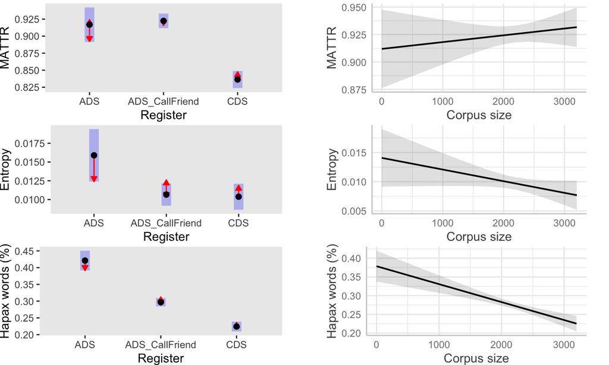

## Q1/2) What are the differences in segmentability between CDS and ADS?

|  | Chisq | Df | Pr(>Chisq) |
| --- | --- | --- | --- |
| (Intercept) | 6147.9687383 | 1 | 0.000000e+00 |
| algo | 2607.8273033 | 8 | 0.000000e+00 |
| type | 98.4134782 | 2 | 4.263681e-22 |
| Unit | 876.7132439 | 1 | 1.132805e-192 |
| algo:type | 1419.2070528 | 16 | 1.208045e-292 |
| algo:Unit | 1781.9871214 | 8 | 0.000000e+00 |
| type:Unit | 0.8309431 | 2 | 6.600290e-01 |
| algo:type:Unit | 1260.9688268 | 16 | 1.214029e-258 |

## main effect of algo

```
## NOTE: Results may be misleading due to involvement in interactions
```

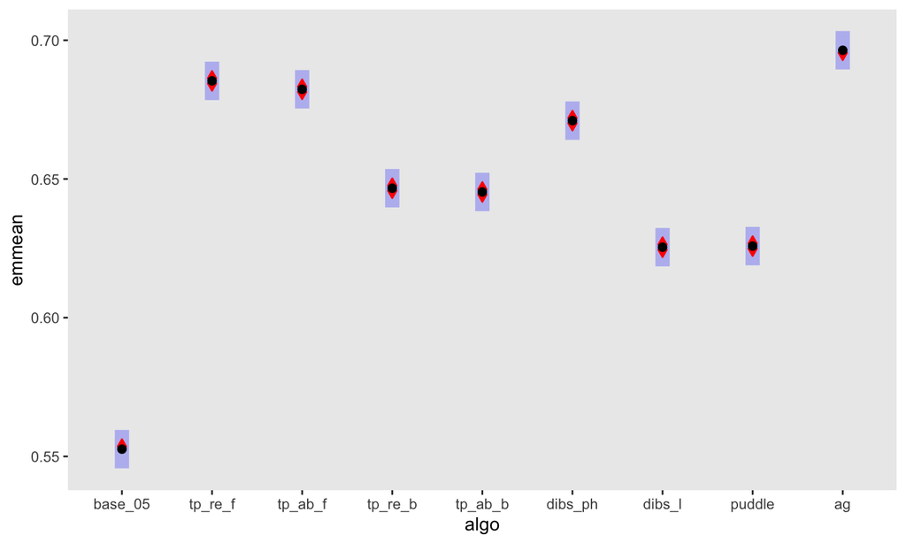

## main effect of type

```
## NOTE: Results may be misleading due to involvement in interactions
```

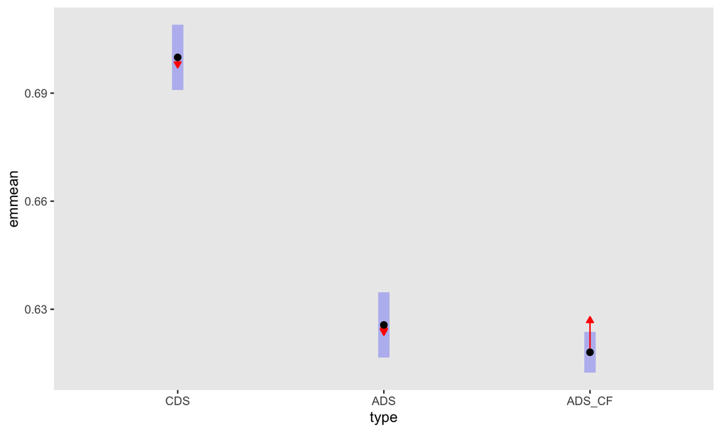

## interaction effect of algo * type *Unit

[figure not shown]

## interaction effect of algo * type *Unit

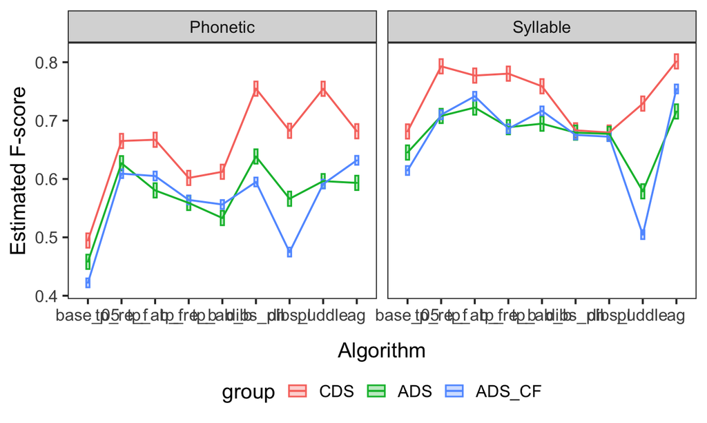

## main effect of unit

```
## NOTE: Results may be misleading due to involvement in interactions
```

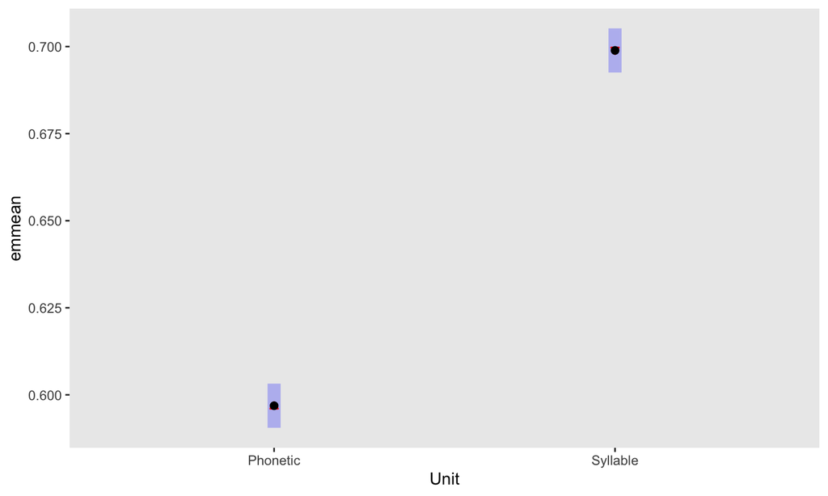

## Q3) How do corpus properties affect word segmentation? (mlm)

|  | Chisq | Df | Pr(>Chisq) |
| --- | --- | --- | --- |
| (Intercept) | 3.082456e+02 | 1 | 5.265114e-69 |
| each_words_tokens | 2.602603e-01 | 1 | 6.099414e-01 |
| proportion_of_single_word_utt | 8.060744e-04 | 1 | 9.773499e-01 |
| algo | 4.859053e+01 | 8 | 7.616427e-08 |
| phrase_s | 4.249574e+01 | 1 | 7.083626e-11 |
| word_s | 5.126698e+01 | 1 | 8.062048e-13 |
| each_mattr | 3.630320e+00 | 1 | 5.673590e-02 |
| each_entropy | 2.299968e-02 | 1 | 8.794579e-01 |
| proportion_of_hapaxes_words | 1.856163e+00 | 1 | 1.730683e-01 |
| type | 1.593887e+01 | 2 | 3.458736e-04 |

[output cut: 11 more lines]

## Interaction effects: algo * corpus properties

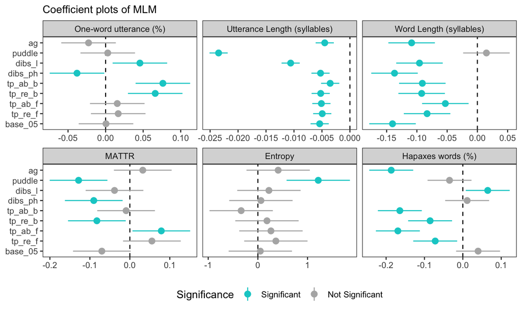

## main effect of algo

```
## NOTE: Results may be misleading due to involvement in interactions
```

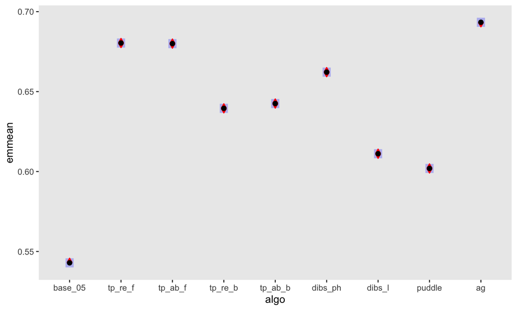

## main effect of type

```
## NOTE: Results may be misleading due to involvement in interactions
```

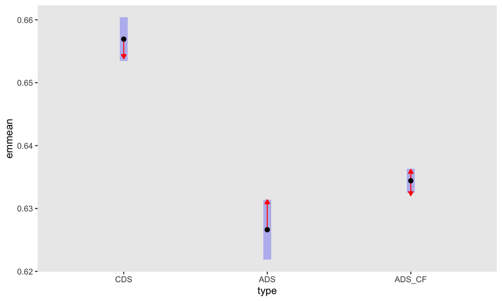

## interaction effect of algo * type * unit

[figure not shown]

## interaction effect of algo * type * unit

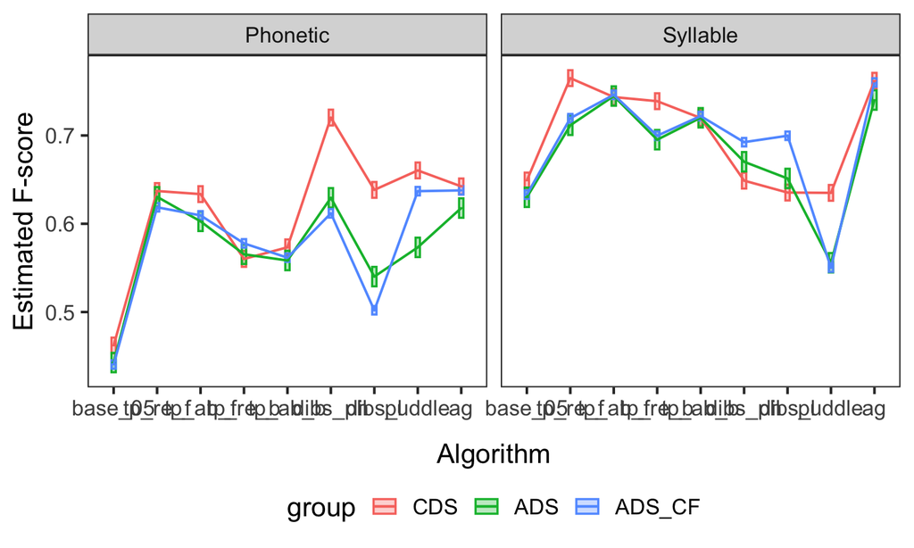

## main effect of unit

```
## NOTE: Results may be misleading due to involvement in interactions
```

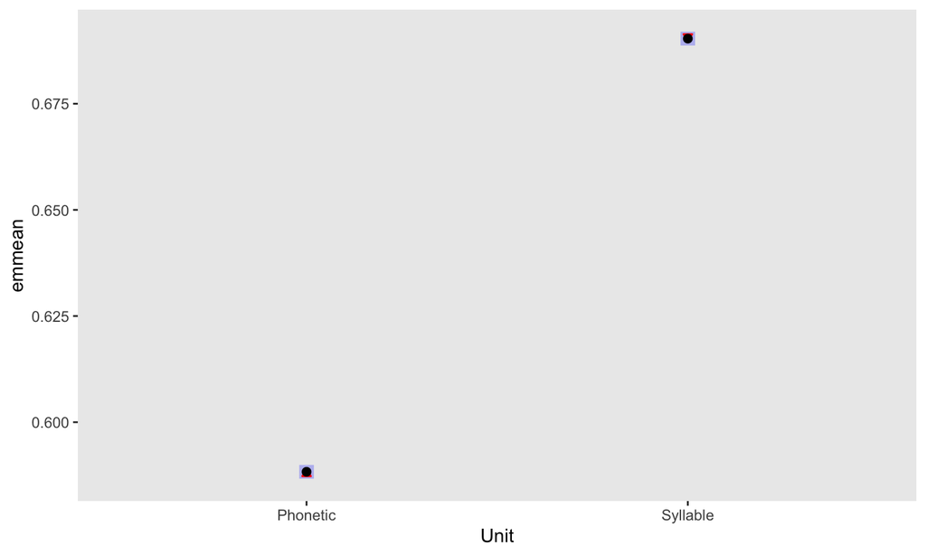

## Q3) How do corpus properties affect word segmentation? (lm’s)

## ANOVA Q3) How do corpus properties affect word segmentation? (lm’s)

|  | Chisq | Df | Pr(>Chisq) |
| --- | --- | --- | --- |
| (Intercept) | 2177.6080406 | 1 | 0.000000e+00 |
| values | 197.3727338 | 1 | 7.819495e-45 |
| algo | 864.8001508 | 8 | 2.205748e-181 |
| each_words_tokens | 0.3040862 | 1 | 5.813320e-01 |
| type | 101.9357655 | 2 | 7.327060e-23 |
| Unit | 1240.0812564 | 1 | 1.187523e-271 |
| values:algo | 433.7333515 | 8 | 1.128361e-88 |
| algo:type | 1773.3452284 | 16 | 0.000000e+00 |
| algo:Unit | 1130.5912581 | 8 | 9.466950e-239 |
| type:Unit | 1.1715409 | 2 | 5.566768e-01 |

[output cut: 1 more lines]

## ANOVA Q3) How do corpus properties affect word segmentation? (lm’s)

|  | Chisq | Df | Pr(>Chisq) |
| --- | --- | --- | --- |
| (Intercept) | 9716.833484 | 1 | 0.000000e+00 |
| values | 590.559467 | 1 | 1.893290e-130 |
| algo | 1752.525951 | 8 | 0.000000e+00 |
| each_words_tokens | 9.308346 | 1 | 2.281123e-03 |
| type | 5.886441 | 2 | 5.269574e-02 |
| Unit | 1700.957449 | 1 | 0.000000e+00 |
| values:algo | 1295.290194 | 8 | 2.450087e-274 |
| algo:type | 1394.938499 | 16 | 1.993301e-287 |
| algo:Unit | 1550.775494 | 8 | 0.000000e+00 |
| type:Unit | 1.606944 | 2 | 4.477716e-01 |

[output cut: 1 more lines]

## ANOVA Q3) How do corpus properties affect word segmentation? (lm’s)

|  | Chisq | Df | Pr(>Chisq) |
| --- | --- | --- | --- |
| (Intercept) | 1829.518013 | 1 | 0.000000e+00 |
| values | 393.697297 | 1 | 1.297122e-87 |
| algo | 606.179137 | 8 | 1.098349e-125 |
| each_words_tokens | 1.705771 | 1 | 1.915350e-01 |
| type | 78.537015 | 2 | 8.828846e-18 |
| Unit | 1360.402741 | 1 | 8.454461e-298 |
| values:algo | 548.475082 | 8 | 2.761456e-113 |
| algo:type | 1683.278005 | 16 | 0.000000e+00 |
| algo:Unit | 1240.289246 | 8 | 1.888177e-262 |
| type:Unit | 1.285212 | 2 | 5.259201e-01 |

[output cut: 1 more lines]

## ANOVA Q3) How do corpus properties affect word segmentation? (lm’s)

|  | Chisq | Df | Pr(>Chisq) |
| --- | --- | --- | --- |
| (Intercept) | 285.9617280 | 1 | 3.771205e-64 |
| values | 25.1614959 | 1 | 5.272442e-07 |
| algo | 76.0296337 | 8 | 3.067482e-13 |
| each_words_tokens | 24.2770808 | 1 | 8.342585e-07 |
| type | 47.5835943 | 2 | 4.648938e-11 |
| Unit | 939.1085992 | 1 | 3.092286e-206 |
| values:algo | 60.6203449 | 8 | 3.521435e-10 |
| algo:type | 1047.8397425 | 16 | 6.349578e-213 |
| algo:Unit | 856.1922594 | 8 | 1.583918e-179 |
| type:Unit | 0.8872033 | 2 | 6.417210e-01 |

[output cut: 1 more lines]

## ANOVA Q3) How do corpus properties affect word segmentation? (lm’s)

|  | Chisq | Df | Pr(>Chisq) |
| --- | --- | --- | --- |
| (Intercept) | 2605.052852 | 1 | 0.000000e+00 |
| values | 120.995950 | 1 | 3.829129e-28 |
| algo | 672.605306 | 8 | 5.643299e-140 |
| each_words_tokens | 0.815619 | 1 | 3.664642e-01 |
| type | 155.947895 | 2 | 1.368815e-34 |
| Unit | 1076.376222 | 1 | 4.502241e-236 |
| values:algo | 174.234168 | 8 | 1.670049e-33 |
| algo:type | 1649.140099 | 16 | 0.000000e+00 |
| algo:Unit | 981.340167 | 8 | 1.590618e-206 |
| type:Unit | 1.016884 | 2 | 6.014319e-01 |

[output cut: 1 more lines]

## ANOVA Q3) How do corpus properties affect word segmentation? (lm’s)

|  | Chisq | Df | Pr(>Chisq) |
| --- | --- | --- | --- |
| (Intercept) | 520.7839625 | 1 | 2.857464e-115 |
| values | 4.3162504 | 1 | 3.775002e-02 |
| algo | 177.9210214 | 8 | 2.812598e-34 |
| each_words_tokens | 19.9249876 | 1 | 8.054075e-06 |
| type | 101.2073177 | 2 | 1.054654e-22 |
| Unit | 910.9115924 | 1 | 4.166654e-200 |
| values:algo | 88.4947950 | 8 | 9.394513e-16 |
| algo:type | 1344.1485491 | 16 | 1.643924e-276 |
| algo:Unit | 830.4848396 | 8 | 5.525909e-174 |
| type:Unit | 0.8605647 | 2 | 6.503254e-01 |

[output cut: 1 more lines]

## interaction effects: algo * corpus properties

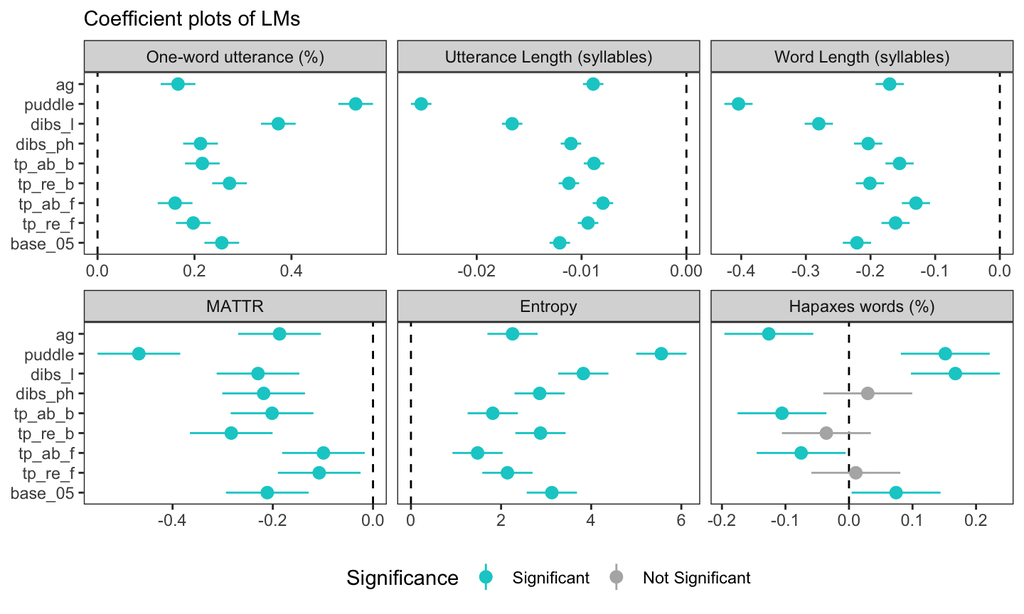